# Latent Variable Model

We can use a dimension reduction technique to create correlation between stocks by building a covariance matrix with latent factor loading. That sounds complicated but is relatively straightforward to code. See `gllvm` for an R package that does that.

If we want the error for some stocks to be correlated, then for year $t$, across all stocks,

$$\boldsymbol{\epsilon}_t \sim N(\mathbf{0}, \Sigma),$$
where $\Sigma$ is a covariance matrix. We can induce a flexible low dimension covariance matrix by adding some unique random effects such that for some unobserved variables per year $z_t$, that capture the underlying factors driving stock abundance within each year, and factor loading $\boldsymbol{\lambda}_s$ per stock,

$$\mathbf{z}_t \sim N(\mathbf{0}, \text{I}).$$
We will start with two latent variables, and write

$$\log(R_i/S_i) = \alpha_{s_i} + u_{t_i} - \beta_{s_i} S_i + \mathbf{z}_{t_i}\cdot\boldsymbol{\lambda}_{s_i} + \epsilon_i,$$
where $u_t$ is the AR(1) year effect shared by all stocks from Module 5.

Fitting this model gives the residual covariance matrix,

$$\Sigma = \boldsymbol{\lambda} \boldsymbol{\lambda}^T + \text{diag}(\sigma^2_j).$$
Positive covariance indicates where the stocks tend to vary similarly each year, and negative would be stocks that perform differently. This is the covariance left after the shared year effect $u_t$ is taken out. The year effect adds the same amount to every pair of stocks.

```r
library(RTMB)

## Remove Harrison and Cultus?
# sox <- sox %>% filter(!PopName %in% c("Harrison", "Cultus"))

sox$stock <- as.numeric(factor(sox$PopName))
nstocks <- max(sox$stock)
sox <- sox %>% mutate(time = yr - min(yr) + 1)
nyears <- max(sox$time)
minyear <- min(sox$yr)
sox$logRS <- log(sox$recruits/sox$spawners)
nobs <- nrow(sox)
stock_names <- sox %>% select(stock, PopName, MU) %>% distinct() %>% arrange(stock)

## One function for both versions of the model in this document. The switch is
## fixed when the function is made, not read from a global variable (see Module 6).
make_negll <- function(penalize){
  function(pars){

    getAll(pars, sox, warn = FALSE)
    beta <- exp(logbeta)

    logRS <- OBS(logRS)

    sigma <- exp(logsigma)
    sigma_re <- exp(logsigma_re)
    sigma_time <- exp(logsigma_time)
    sigma_obs <- sigma[stock]
    scale_z <- exp(logscale_z)
    phi <- 2*plogis(logitphi)-1

    alpha_stock <- re + alpha0
    ADREPORT(alpha_stock)

    ## One line for all observations: quicker to tape than a loop over rows
    mu <- alpha_stock[stock] + re_time[time] - beta[stock]*spawners_scaled +
      z[time,1]*lambda1[stock]*scale_z[1] + z[time,2]*lambda2[stock]*scale_z[2]

    ## Use this for built in residuals
    ll <- dautoreg(re_time,phi=phi,scale=sqrt(sigma_time^2/(1-phi^2)), log=TRUE)
    ## Add in latent variables
    for( i in 1:2 ) ll <- ll + sum(dnorm(z[,i], 0, 1, log = TRUE))

    ll <- ll + sum(dnorm(re, 0, sigma_re, log = TRUE))
    ll <- ll + sum(dnorm(logRS, mu, sigma_obs, log = TRUE))

    ## Penalties: explained and used further down
    if(penalize){
      ll <- ll + sum(dnorm(lambda1, 0, 1, log = TRUE)) + sum(dnorm(lambda2, 0, 1, log = TRUE))
      ll <- ll + sum(dgamma(sigma, shape = 2, rate = 2, log = TRUE))
    }

    REPORT(mu)
    REPORT(re_time)
    REPORT(sigma_obs)

    return(-ll)
  }
}

## Factor models can have more than one local optimum, so we fit from several
## starting points. The seed makes each start reproducible.
fit_lvm <- function(seed, penalize){
  set.seed(seed)
  parameters <- list(
    alpha0 = runif(1, 1, 3),
    re = rnorm(nstocks, 0, 0.1),
    logbeta = runif(nstocks, -1, 0),
    logsigma = runif(nstocks, -0.5, 0.5),
    logsigma_re = log(0.5),
    re_time = rep(0, nyears),
    logitphi = 0,
    logsigma_time = log(0.5),
    z = matrix(0, nrow = nyears, ncol = 2),
    logscale_z = c(0,0),
    lambda1 = c(1, rnorm(nstocks-1, 0, 0.5)),
    lambda2 = c(0,1, rnorm(nstocks-2, 0, 0.5))
  )
  obj <- MakeADFun(func = make_negll(penalize), parameters = parameters, random = c("re", "re_time", "z"),
    map = list(lambda1 = factor(c(NA, 2:nstocks)), lambda2 = factor(c(NA, NA, 3:nstocks))),
    silent = TRUE)
  fit <- nlminb(obj$par, obj$fn, obj$gr, control = list(eval.max = 1e4, iter.max = 1e4))
  list(obj = obj, fit = fit)
}

## For each fit: the objective, what the optimizer said, and the smallest residual SD
summarize_fits <- function(fits){
  logsigma <- lapply(fits, function(f) f$fit$par[names(f$fit$par) == "logsigma"])
  data.frame(
    objective = round(sapply(fits, function(f) f$fit$objective), 2),
    message = sapply(fits, function(f) f$fit$message),
    smallest_sigma = signif(sapply(logsigma, function(l) exp(min(l))), 2),
    stock = sapply(logsigma, function(l) stock_names$PopName[which.min(l)])
  )
}

fits <- lapply(1:4, fit_lvm, penalize = FALSE)
summarize_fits(fits)
```

```
  objective                  message smallest_sigma        stock
1   1598.78 relative convergence (4)        1.0e-04 Scotch Creek
2   1606.40 relative convergence (4)        1.8e-04      Seymour
3   1599.10    false convergence (8)        1.2e-06 Scotch Creek
4   1599.02    false convergence (8)        6.4e-07 Scotch Creek
```

Four starting points do not give one answer: the objective differs between them, and not every fit converges. They do have one thing in common. In each, the residual standard deviation of one stock is essentially zero. The model has used a factor to follow that stock exactly, year by year.

This is very suspicious, and it is not telling us something about that stock. It is a well known failure of factor models, called a Heywood case. R’s own `factanal()` guards against it by not letting a variance go below a small bound. The best fit sits at the edge of the parameter space, $\sigma = 0$. On the log scale that is minus infinity, which the optimizer can approach but never reach, and that is where the convergence trouble comes from.

## Keeping the model away from the edge

Penalizing the model will help. We add two terms to the log-likelihood (the `penalize` block in the function above):

- A normal density, $N(0, 1)$, on the factor loadings. This pulls loadings that the data say little about towards zero.
- A gamma density with shape 2 on the residual standard deviations. Its density is zero at $\sigma = 0$, so it keeps each $\sigma$ away from the edge, and it is mild over the values we expect.

Note that the strength of both is fixed. It is tempting to estimate the strength of a penalty as one more parameter, but the optimizer would then set it to zero and switch the penalty off, exactly as with the smoothing parameter in the GAM example. These terms are weak priors, and the estimates are now penalized (or “maximum a posteriori”) estimates.

```r
fits_pen <- lapply(1:4, fit_lvm, penalize = TRUE)
summarize_fits(fits_pen)
```

```
  objective                  message smallest_sigma        stock
1   1654.15 relative convergence (4)           0.19 Scotch Creek
2   1657.55 relative convergence (4)           0.25 Scotch Creek
3   1654.15 relative convergence (4)           0.19 Scotch Creek
4   1657.55 relative convergence (4)           0.25 Scotch Creek
```

```r
## Keep the best of the four and check it
best <- fits_pen[[which.min(sapply(fits_pen, function(f) f$fit$objective))]]
obj <- best$obj
fit <- best$fit
sdreport(obj)$pdHess
```

```
[1] TRUE
```

Every start now converges, no residual standard deviation is near zero, and the Hessian is positive definite. There are still two different local optima, which is why we fitted from several starts and kept the best. Try other strengths for the two penalties: does the picture below change?

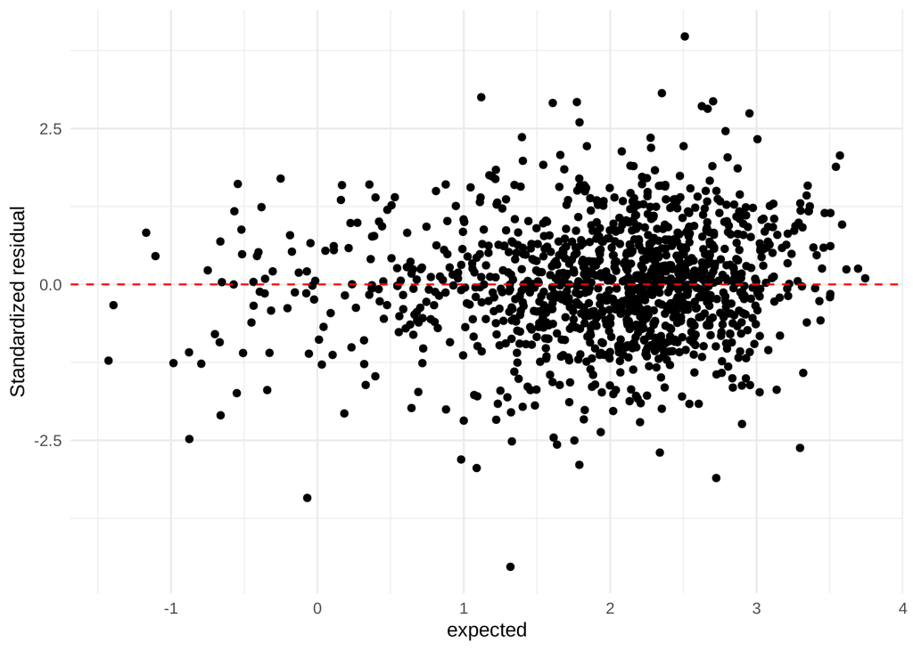

```r
rep <- obj$report(obj$env$last.par.best)   ## report at the best parameters found
sox$expected <- rep$mu
sox$sigma <- rep$sigma_obs
re_time <- rep$re_time

sox <- sox %>%
  mutate(resid = logRS - expected) %>%
  mutate(resid_std = resid/sigma)

ggplot(data = sox, aes(x = expected, y = resid_std)) +
  geom_point() + theme_minimal() +
  geom_hline(yintercept = 0, col = 'red', linetype = 2) +
  ylab("Standardized residual")
```

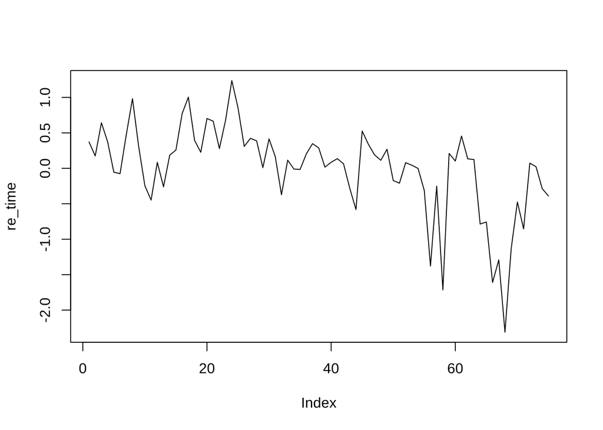

```r
plot(re_time, type = 'l')
```

By fitting a covariance matrix between stocks, we can use that to cluster them into stocks based on similarity in response each year.

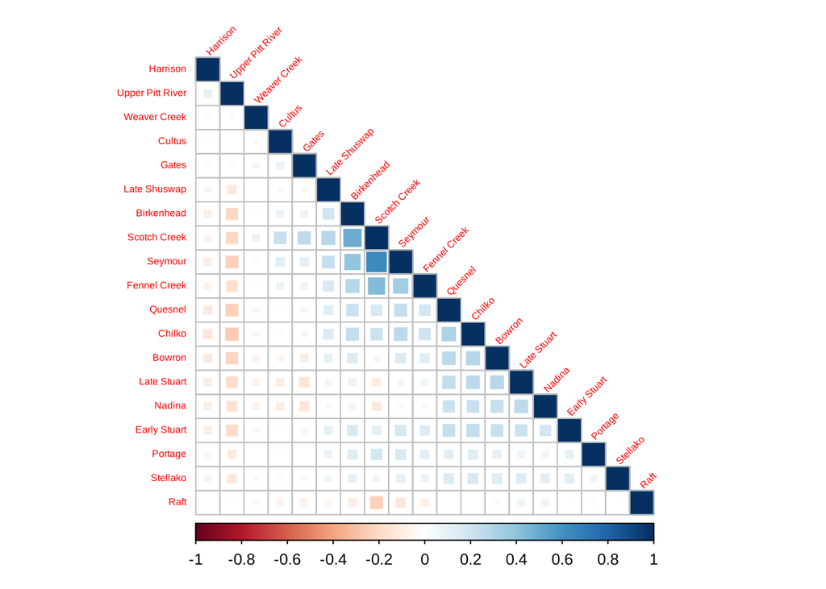

```r
## Stock Covariance
## Extract fitted parameters as a list
pList <- obj$env$parList(fit$par, obj$env$last.par.best)

## Factor loading matrix: what multiplies z in the model
Lambda <- cbind(pList$lambda1*exp(pList$logscale_z[1]),
  pList$lambda2*exp(pList$logscale_z[2]))
sigma <- exp(pList$logsigma)


## Covariance between stocks from the two factors
## (what is left once the year effect shared by all stocks is taken out)
Sigma_latent <- Lambda %*% t(Lambda) + diag(sigma^2)
colnames(Sigma_latent) <- stock_names$PopName
rownames(Sigma_latent) <- stock_names$PopName

library(corrplot); library(gclus);
Cor_latent <- cov2cor(Sigma_latent)
Cor_latent_ord <- Cor_latent[order.single(Cor_latent), order.single(Cor_latent)]

corrplot(Cor_latent_ord, diag = TRUE, type = "lower",
         method = "square", tl.cex = 0.5, tl.srt = 45, tl.col = "red")
```

```r
## The shared year effect adds the same covariance to every pair of stocks.
## Mean correlation between two stocks, without it and with it:
phi <- 2*plogis(pList$logitphi) - 1
var_year <- exp(pList$logsigma_time)^2/(1 - phi^2)
Cor_total <- cov2cor(Sigma_latent + var_year)
pairs <- upper.tri(Cor_latent)
round(c(factors_only = mean(Cor_latent[pairs]), with_year_effect = mean(Cor_total[pairs])), 2)
```

```
    factors_only with_year_effect
            0.06             0.39
```

The plot shows which stocks move together *beyond* what all stocks share. Most of the correlation between two stocks comes from the shared year effect, as the two numbers above show.

The loadings themselves need one more step before we look at them. The two axes are only identified up to a rotation. In this model the axes are fixed by setting the second loading of the first stock in the alphabet (Birkenhead) to zero, so “Latent Variable 1” and “Latent Variable 2” have no meaning of their own. Rotating to a standard position (varimax) makes the plot easier to read, and it changes nothing about the fit: $\boldsymbol{\lambda}\boldsymbol{\lambda}^T$, and so every correlation above, stays the same.

```r
Lambda_rot <- unclass(varimax(Lambda)$loadings)
max(abs(Lambda_rot %*% t(Lambda_rot) - Lambda %*% t(Lambda)))   ## the covariance has not changed
```

```
[1] 2.220446e-16
```

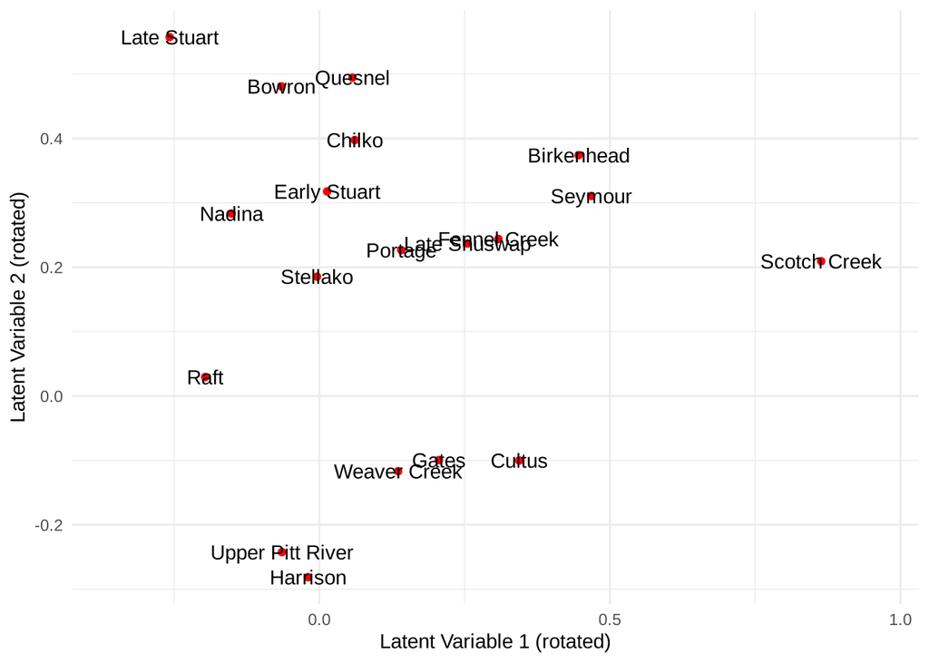

```r
colnames(Lambda_rot) <- c("lambda_1", "lambda_2")
stock_names <- cbind(stock_names, Lambda_rot)
stock_names$sigma <- sigma

ggplot(stock_names, aes(x = lambda_1, y = lambda_2)) + geom_point(colour = "red") +
  theme_minimal() + xlab("Latent Variable 1 (rotated)") + ylab("Latent Variable 2 (rotated)") +
  scale_x_continuous(expand = expansion(mult = 0.15)) +   ## room for the labels at the edges
  geom_text(aes(label = PopName))
```

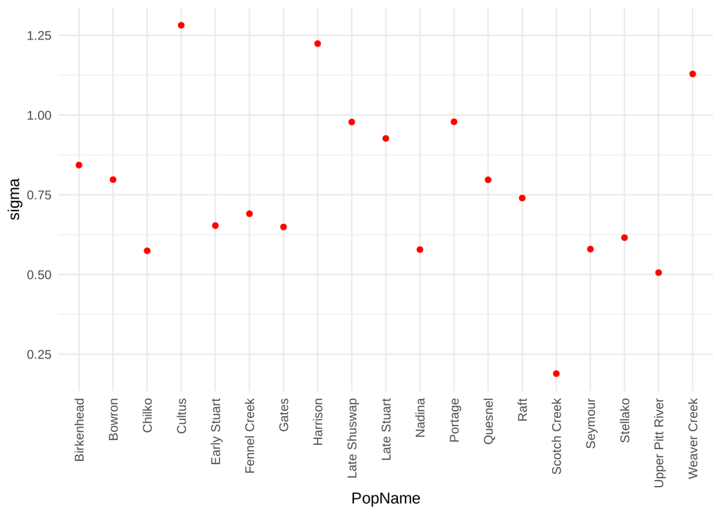

```r
ggplot(stock_names, aes(x = PopName, y = sigma)) + geom_point(colour = "red") +
  theme_minimal() +
  theme(axis.text.x = element_text(angle = 90, vjust = 0.5, hjust = 1))
```

Packages that fit this kind of model for you, and handle the rotation: `gllvm`, `glmmTMB` (the `rr()` covariance structure), and `MARSS` or `bayesdfa` for dynamic factor analysis. They are good to check a hand-coded model against.